# PM 566 Assignment 3

Author

Erica Shin

## **Text Mining**

A new dataset has been added to the data science data repository https://github.com/USCbiostats/data-science-data/tree/master/03_pubmed. The dataset contains 3,241 abstracts from articles collected via 5 PubMed searches. The search terms are listed in the second column, `term` and these will serve as the “documents.” Your job is to analyse these abstracts to find interesting insights.

```r
# Loading libraries
library(tidytext)
library(dplyr)
library(ggplot2)
library(forcats)
library(textdata)
library(stringr)
library(knitr)
library(kableExtra)
```

```r
# Reading in dataset
pubmed <- read.csv("/Users/ericashin/Downloads/pubmed.csv")

head(pubmed)
```

```
                                                                                                                                                                                                                                                                                                            …
1                                                                                                                                                                                                                                                                                                           …
2                                                                                                                                                                                                                                                                                                           …
3                                                                                                                                                                                                                                                                                                           …
4 OBJECTIVE. The objective of our study was to determine the misdiagnosis rate of radiologists for coronavirus disease 2019 (COVID-19) and evaluate the performance of chest CT in the diagnosis and management of COVID-19. The CT features of COVID-19 are reported and compared with the CT features of o…
5                                                                                                                                                                                                                                                                                                           …
6                                                                                                                                                                                                                                                                                                           …
   term
1 covid
2 covid
3 covid
4 covid
5 covid
6 covid
```

```r
colnames(pubmed)
```

```
[1] "abstract" "term"
```

1. **Tokenize the abstracts and count the number of each token. Do you see anything interesting? Does removing stop words change what tokens appear as the most frequent? What are the 5 most common tokens for each search term after removing stopwords?**

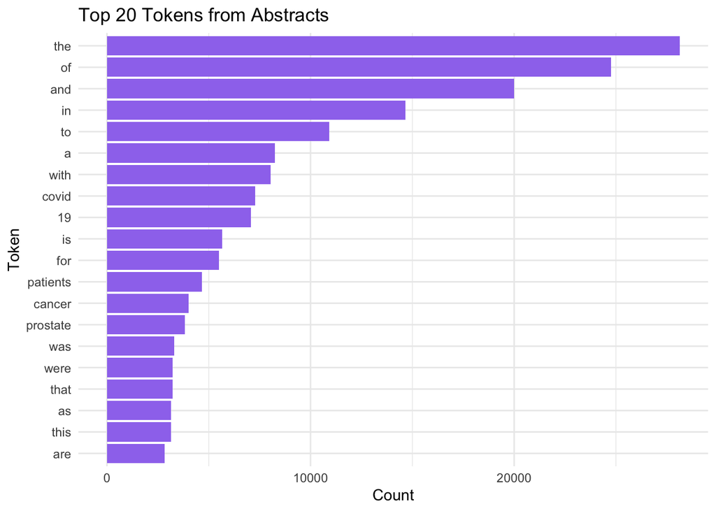

```r
# Tokenizing abstracts and counting number of each token
tokenize <- pubmed |>
  unnest_tokens(token, abstract) |>
  count(token, sort = TRUE) |>
  top_n(20, n)

# Visualization of Top 20 Tokenized Abstracts
tokenize |>
  ggplot(aes(n, fct_reorder(token, n))) +
  geom_col(fill="mediumpurple2") +
  labs(title = "Top 20 Tokens from Abstracts",
       x = "Count",
       y = "Token") +
  theme_minimal()
```

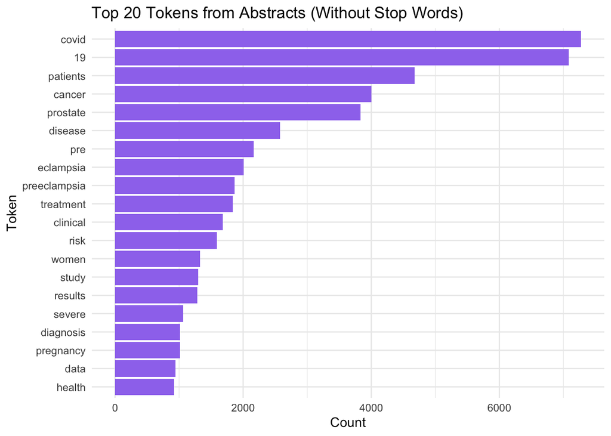

```r
# Removing stop words
no_stop <- pubmed |>
  unnest_tokens(token, abstract) |>
  anti_join(stop_words, by = c("token" = "word")) |>
  count(token, sort = TRUE) |>
  top_n(20, n)

# Visualization of Top 20 Tokenized Abstracts Without Stop Words
no_stop |>
  ggplot(aes(n, fct_reorder(token, n))) +
  geom_col(fill="mediumpurple2") +
  labs(title = "Top 20 Tokens from Abstracts (Without Stop Words)",
       x = "Count",
       y = "Token") +
  theme_minimal()
```

```r
# Five most common tokens for each search term without stop words
common_term <- pubmed |>
  unnest_tokens(token, abstract) |>
  anti_join(stop_words, by = c("token" = "word")) |>
  group_by(term) |>
  count(token, sort = TRUE) |>
  slice_max(n, n = 5)

# Table of five most common tokens for each search term without stop words
kable(common_term, caption = "5 Most Common Tokens for Each Search Term (Without Stop Words)")
```

5 Most Common Tokens for Each Search Term (Without Stop Words)

| term | token | n |
| --- | --- | --- |
| covid | covid | 7275 |
| covid | 19 | 7035 |
| covid | patients | 2293 |
| covid | disease | 943 |
| covid | pandemic | 800 |
| cystic fibrosis | fibrosis | 867 |
| cystic fibrosis | cystic | 862 |
| cystic fibrosis | cf | 625 |
| cystic fibrosis | patients | 586 |
| cystic fibrosis | disease | 400 |
| meningitis | patients | 446 |
| meningitis | meningitis | 429 |
| meningitis | meningeal | 219 |
| meningitis | csf | 206 |
| meningitis | clinical | 187 |
| preeclampsia | pre | 2038 |
| preeclampsia | eclampsia | 2005 |
| preeclampsia | preeclampsia | 1863 |
| preeclampsia | women | 1196 |
| preeclampsia | pregnancy | 969 |
| prostate cancer | cancer | 3840 |
| prostate cancer | prostate | 3832 |
| prostate cancer | patients | 934 |
| prostate cancer | treatment | 926 |
| prostate cancer | disease | 652 |

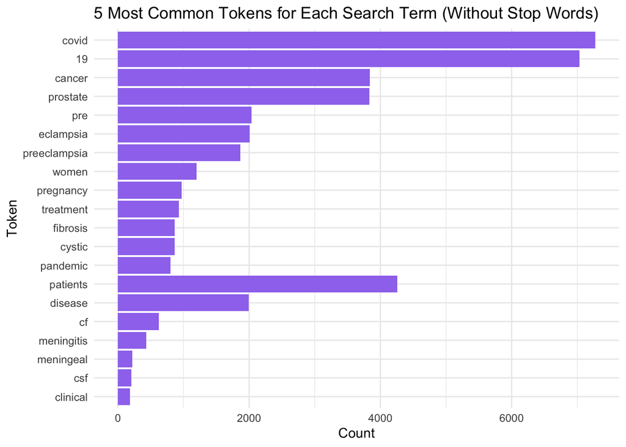

```r
# Visualization of five most common tokens for each search term without stop words
common_term |>
  ggplot(aes(n, fct_reorder(token, n))) +
  geom_col(fill="mediumpurple2") +
  labs(title = "5 Most Common Tokens for Each Search Term (Without Stop Words)",
       x = "Count",
       y = "Token") +
  theme_minimal()
```

Removing stop words does change what tokens appear as the most frequent. Before removing stop words, the top 20 most frequent tokens included many stop words such as “the,” “of,” “and,” “in,” were”, “are,” and more. These tokens did not provide particularly helpful insight due to the inundation of stop words. After removing stop words, the top 20 most frequent tokens included more key terms related to medical conditions, specific populations, and other relevant clinical terms that provided more specific insight.

After removing stop words, the five most common tokens for each search term include the following:

- **covid**: covid, 19, patients, disease, pandemic
- **cystic fibrosis**: fibrosis, cystic, cf, patients, disease
- **meningitis**: patients, meningitis, meningeal, csf, clinical
- **preelampsia**: pre, eclampsia, preeclampsia, women, pregancy
- **prostate cancer**: cancer, prostate, patients, treatment, disease
2. **Tokenize the abstracts into bigrams. Find the 10 most common bigrams and visualize them with ggplot2.**

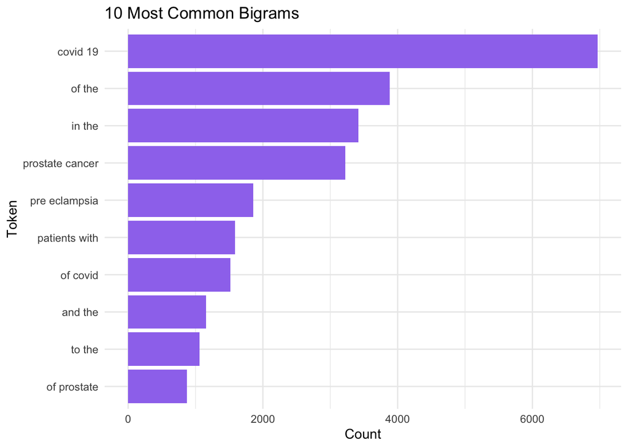

```r
# Tokenize into bigrams
bigram <- pubmed |>
  unnest_ngrams(ngram, abstract, n=2) |>
  count(ngram, sort=TRUE) |>
  slice_max(n, n = 10)

bigram |>
  ggplot(aes(n, fct_reorder(ngram, n))) +
  geom_col(fill="mediumpurple2") +
  labs(title = "10 Most Common Bigrams",
       x = "Count",
       y = "Token") +
  theme_minimal()
```

3. **Calculate the TF-IDF value for each word-search term combination (here you want the search term to be the “document”). What are the 5 tokens from each search term with the highest TF-IDF value? How are the results different from the answers you got in question 1?**

```r
# Calculating TF-IDF value for each word-search term combination
tfidf <- pubmed |>
  unnest_tokens(abstract, abstract) |>
  count(abstract, term) |>
  bind_tf_idf(abstract, term, n) |>
  arrange(desc(tf_idf))

head(tfidf)
```

```
      abstract            term    n          tf       idf     tf_idf
1        covid           covid 7275 0.037105042 1.6094379 0.05971826
2     prostate prostate cancer 3832 0.031188957 1.6094379 0.05019669
3    eclampsia    preeclampsia 2005 0.014278389 1.6094379 0.02298018
4 preeclampsia    preeclampsia 1863 0.013267152 1.6094379 0.02135266
5   meningitis      meningitis  429 0.009194171 1.6094379 0.01479745
6           cf cystic fibrosis  625 0.012718763 0.9162907 0.01165408
```

```r
# TI-IDF Values for the Top 5 Tokens from Each Search Term
top <- pubmed |>
  unnest_tokens(word, abstract) |>
  count(term, word) |>
  group_by(term) |>
  bind_tf_idf(word, term, n) |>
  arrange(desc(tf_idf)) |>
  slice_max(order_by = tf_idf, n = 5)

# Table of TI-IDF Values for the Top 5 Tokens from Each Search Term
kable(top, caption = "TI-IDF Values for the Top 5 Tokens from Each Search Term") |>
  kable_styling(full_width = F, position = "left")
```

TI-IDF Values for the Top 5 Tokens from Each Search Term

| term | word | n | tf | idf | tf_idf |
| --- | --- | --- | --- | --- | --- |
| covid | covid | 7275 | 0.0371050 | 1.6094379 | 0.0597183 |
| covid | pandemic | 800 | 0.0040803 | 1.6094379 | 0.0065670 |
| covid | coronavirus | 647 | 0.0032999 | 1.6094379 | 0.0053110 |
| covid | sars | 372 | 0.0018973 | 1.6094379 | 0.0030536 |
| covid | cov | 334 | 0.0017035 | 1.6094379 | 0.0027417 |
| cystic fibrosis | cf | 625 | 0.0127188 | 0.9162907 | 0.0116541 |
| cystic fibrosis | fibrosis | 867 | 0.0176435 | 0.5108256 | 0.0090127 |
| cystic fibrosis | cystic | 862 | 0.0175417 | 0.5108256 | 0.0089608 |
| cystic fibrosis | cftr | 86 | 0.0017501 | 1.6094379 | 0.0028167 |
| cystic fibrosis | sweat | 83 | 0.0016891 | 1.6094379 | 0.0027184 |
| meningitis | meningitis | 429 | 0.0091942 | 1.6094379 | 0.0147974 |
| meningitis | meningeal | 219 | 0.0046935 | 1.6094379 | 0.0075539 |
| meningitis | pachymeningitis | 149 | 0.0031933 | 1.6094379 | 0.0051394 |
| meningitis | csf | 206 | 0.0044149 | 0.9162907 | 0.0040453 |
| meningitis | meninges | 106 | 0.0022718 | 1.6094379 | 0.0036562 |
| preeclampsia | eclampsia | 2005 | 0.0142784 | 1.6094379 | 0.0229802 |
| preeclampsia | preeclampsia | 1863 | 0.0132672 | 1.6094379 | 0.0213527 |
| preeclampsia | pregnancy | 969 | 0.0069006 | 0.5108256 | 0.0035250 |
| preeclampsia | maternal | 797 | 0.0056757 | 0.5108256 | 0.0028993 |
| preeclampsia | gestational | 191 | 0.0013602 | 1.6094379 | 0.0021891 |
| prostate cancer | prostate | 3832 | 0.0311890 | 1.6094379 | 0.0501967 |
| prostate cancer | androgen | 305 | 0.0024824 | 1.6094379 | 0.0039953 |
| prostate cancer | psa | 282 | 0.0022952 | 1.6094379 | 0.0036940 |
| prostate cancer | prostatectomy | 215 | 0.0017499 | 1.6094379 | 0.0028164 |
| prostate cancer | castration | 148 | 0.0012046 | 1.6094379 | 0.0019387 |

The five tokens with the highest TF-IDF values for each search term include the following:

- **covid**: covid, pandemic, coronavirus, sars, and cov.
- **cystic fibrosis**: cf, fibrosis, cystic, cftr, and sweat.
- **meningitis**: meningitis, meningeal, pachymeningitis, csf, and meninges.
- **preelampsia**: eclampsia, preeclampsia, pregnancy, maternal, and gestational.
- **prostate cancer**: prostate, androgen, psa, prostatectomy, and castration.

While there is some overlap with the tokens for each search term in Question 1 and Question 3, the Question 3 tokens tend to be more specific to the search term and don’t include as many generic medical words (e.g., patients, disease, treatment) that show up in the Question 1 tokens. For example, while the Question 1 tokens include “patients,” “treatment,” and “disease” for the search term “prostate cancer,” the Question 3 tokens have more specific terms such as “androgen,” “psa,” “prostatectomy,” and “castration” that are more related and can give more particular insight about this medical disease compared to the other words such as “patients.”

## **Sentiment Analysis**

1. **Perform a sentiment analysis using the NRC lexicon. What is the most common sentiment for each search term? What if you remove `"positive"` and `"negative"` from the list?**

```r
# NRC lexicon
get_sentiments('nrc')
```

```
# A tibble: 13,872 × 2
   word        sentiment
   <chr>       <chr>
 1 abacus      trust
 2 abandon     fear
 3 abandon     negative
 4 abandon     sadness
 5 abandoned   anger
 6 abandoned   fear
 7 abandoned   negative
 8 abandoned   sadness
 9 abandonment anger
10 abandonment fear
# ℹ 13,862 more rows
```

```r
# Sentiment analysis using NRC lexicon
pubmed_nrc <- pubmed |>
  unnest_tokens(word, abstract) |>
  inner_join(get_sentiments('nrc'), by="word", relationship="many-to-many")

head(pubmed_nrc)
```

```
   term    word sentiment
1 covid disease     anger
2 covid disease   disgust
3 covid disease      fear
4 covid disease  negative
5 covid disease   sadness
6 covid disease     anger
```

```r
# Most common sentiment for each search term
pubmed |>
  unnest_tokens(word, abstract) |>
  inner_join(get_sentiments('nrc'), relationship="many-to-many") |>
  group_by(term) |>
  summarise(sentiment = names(which.max(table(sentiment))))
```

```
# A tibble: 5 × 2
  term            sentiment
  <chr>           <chr>
1 covid           positive
2 cystic fibrosis positive
3 meningitis      negative
4 preeclampsia    positive
5 prostate cancer negative
```

```r
# Removing positive and negative
nrc_fun <- get_sentiments('nrc')
nrc_fun <- nrc_fun[!nrc_fun$sentiment %in% c('positive', 'negative'), ]

pubmed |>
  unnest_tokens(word, abstract) |>
  inner_join(nrc_fun, relationship="many-to-many") |>
  group_by(term) |>
  summarise(sentiment = names(which.max(table(sentiment))))
```

```
# A tibble: 5 × 2
  term            sentiment
  <chr>           <chr>
1 covid           fear
2 cystic fibrosis disgust
3 meningitis      fear
4 preeclampsia    anticipation
5 prostate cancer fear
```

The most common positive terms are “covid,” “cystic fibrosis,” and “preeclampsia.” The most common negative terms are “meningitis” and “prostate cancer.”

When “positive” and “negative” are removed from the sentiments, the top sentiments are fear (“covid,” “meningitis,” and “prostate cancer”), disgust (“cystic fibrosis”), and anticipation (“preeclampsia”).

2. **Now perform a sentiment analysis using the AFINN lexicon to get an average positivity score for each abstract (hint: you may want to create a variable that indexes, or counts, the abstracts). Create a visualization that shows these scores grouped by search term. Are any search terms noticeably different from the others?**

```r
# AFinn lexicon
get_sentiments('afinn')
```

```
# A tibble: 2,477 × 2
   word       value
   <chr>      <dbl>
 1 abandon       -2
 2 abandoned     -2
 3 abandons      -2
 4 abducted      -2
 5 abduction     -2
 6 abductions    -2
 7 abhor         -3
 8 abhorred      -3
 9 abhorrent     -3
10 abhors        -3
# ℹ 2,467 more rows
```

```r
# Sentiment analysis using AFINN lexicon
pubmed_afinn <- pubmed |>
  unnest_tokens(word, abstract) |>
  inner_join(get_sentiments('afinn'), by='word') |>
  group_by(term) |>
  summarise(sentiment = mean(value, na.rm=TRUE))

head(pubmed_afinn)
```

```
# A tibble: 5 × 2
  term            sentiment
  <chr>               <dbl>
1 covid              -0.255
2 cystic fibrosis     0.368
3 meningitis         -0.185
4 preeclampsia       -0.161
5 prostate cancer    -0.226
```

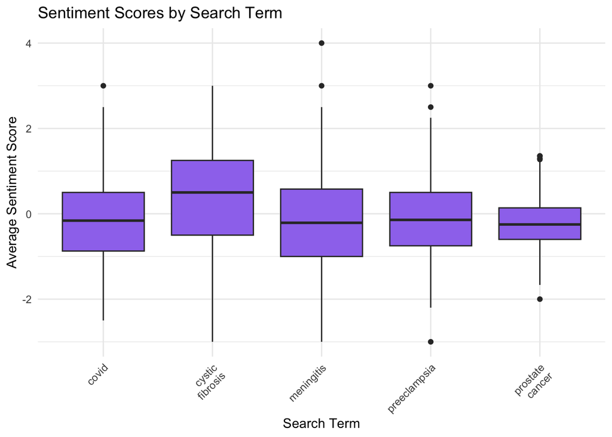

```r
# Abstract scores grouped by search term
pubmed_sent <- pubmed |>
  mutate(abstract_index = row_number()) |>
  unnest_tokens(word, abstract) |>
  inner_join(get_sentiments("afinn"), by = "word") |>
  group_by(abstract_index, term) |>
  summarize(average_score = mean(value, na.rm = TRUE), .groups = "drop") |>
  ungroup()

# Visualization of scores grouped by search term
pubmed_sent |>
  ggplot(aes(x = term, y = average_score)) +
  geom_boxplot(fill = "mediumpurple2") +
  labs(title = "Sentiment Scores by Search Term",
       x = "Search Term",
       y = "Average Sentiment Score") +
  theme_minimal() +
   theme(axis.text.x = element_text(angle = 45, hjust = 1, vjust = 1)) +
  scale_x_discrete(labels = function(x) str_wrap(x, width = 10))
```

The visualization of the average positivity scores for each abstract grouped by search term demonstrates that the term “cystic fibrosis” is the only one with a positive average sentiment score (approximately mean value of 0.5). The other terms (“covid,” “meningitis,” “preeclampsia,” and “prostate cancer”) all have negative average sentiment scores.